# Reprod_Res_Assignment

Roby

July 19, 2015

```r
activity <- read.csv("activity.csv", colClasses = c("numeric","Date","numeric"), header = TRUE)

## ignoring the missing values
data <- na.omit(activity)
```

Total number of steps taken per day

```r
library(plyr)
stepsperday <- ddply(data, .(date), summarize, steps = sum(steps))
```

make a histogram of the total number of steps per day

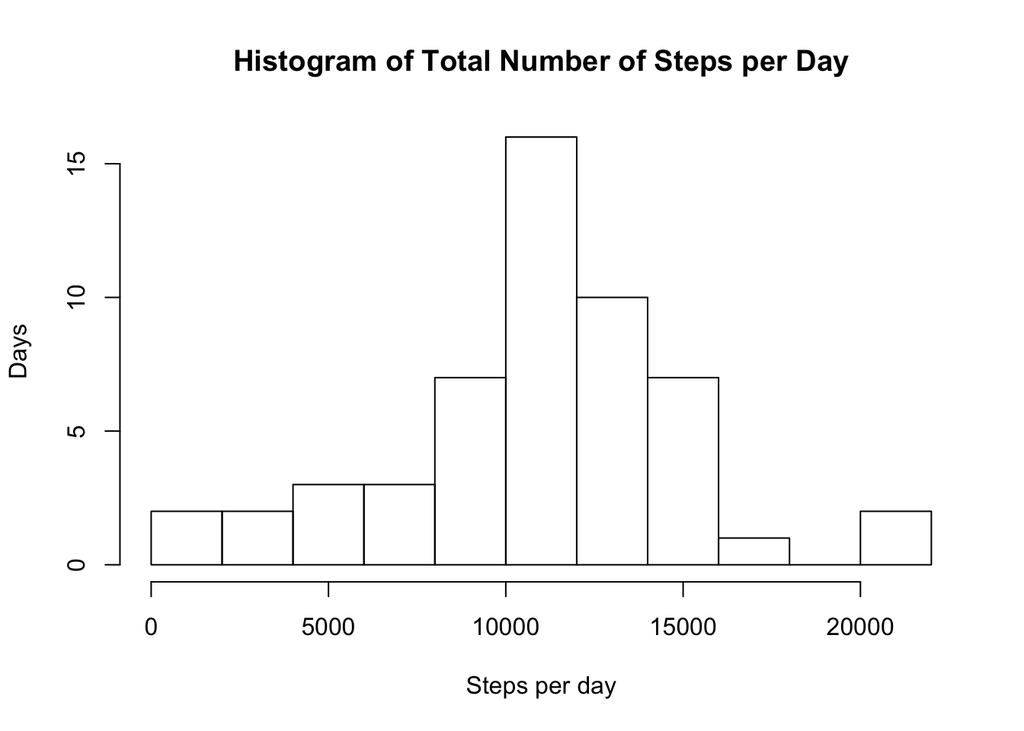

```r
hist(stepsperday$steps, breaks = 10,
     main = "Histogram of Total Number of Steps per Day",
     xlab = "Steps per day", ylab = "Days")
```

Calculating the mean and median number of steps per day

```r
mean_steps <- mean(stepsperday$steps, na.rm = TRUE)
print(paste("The mean total number of steps taken per day is: ", mean_steps))
```

```
## [1] "The mean total number of steps taken per day is:  10766.1886792453"
```

```r
median_steps <- median(stepsperday$steps, na.rm = TRUE)
print(paste("The median total number of steps taken per day is: ", median_steps))
```

```
## [1] "The median total number of steps taken per day is:  10765"
```

Average daily activity pattern

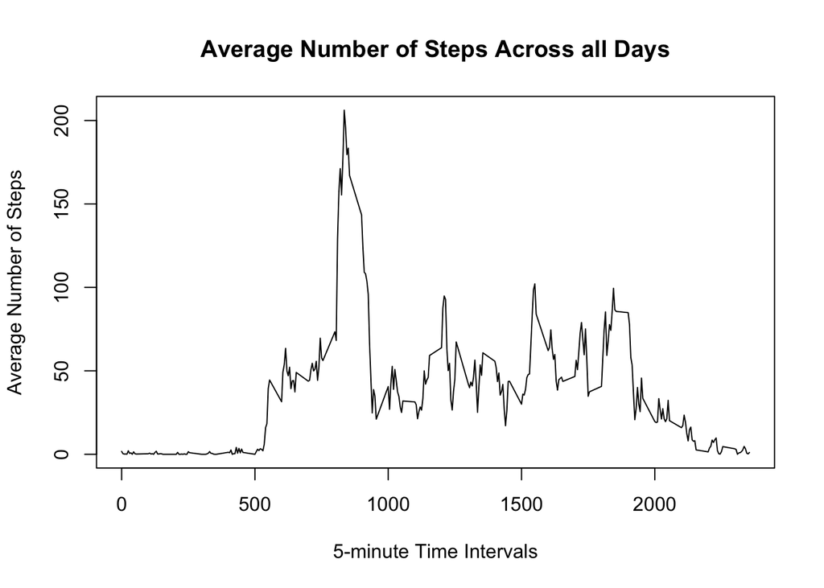

```r
## find daily average number of steps taken
library(plyr)
Average_steps <- ddply(data, .(interval), summarize, steps = mean(steps,na.rm=TRUE))

## make a time series plot of the average number of steps taken (average across all days)
plot(Average_steps$steps ~ Average_steps$interval, type="l",
     main = "Average Number of Steps Across all Days",
     xlab = "5-minute Time Intervals",
     ylab = "Average Number of Steps")
```

```r
## locate the 5-minute interval with the maximum number of steps
PeakIntervalIndex <- which(Average_steps$steps == max(Average_steps$steps))
print(paste("On the ",PeakIntervalIndex,"-th interval, the variable 'steps' reaches its maximum: ", Average_steps$steps[PeakIntervalIndex], sep=""))
```

```
## [1] "On the 104-th interval, the variable 'steps' reaches its maximum: 206.169811320755"
```

Imputing missing values

Calculate and report the total number of missing values in the dataset (i.e. the total number of rows with NA)

```r
Row_Na <- dim(activity) - dim(data)
Row_Na <- Row_Na[1]
print(paste("The total number of rows with NA) is:",Row_Na))
```

```
## [1] "The total number of rows with NA) is: 2304"
```

2 Devise a strategy for filling in all of the missing values in the dataset. The strategy does not need to be sophisticated. For example, you could use the mean/median for that day, or the mean for that 5-minute interval, etc.